# 2016 Election Tweets

Mike

2/16/2020

## EDA

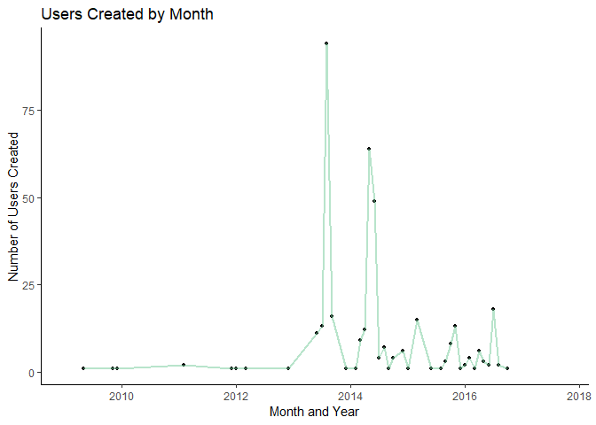

A general graph of tweets over time shows a crescendo of tweets leading upto the November 2016 election.

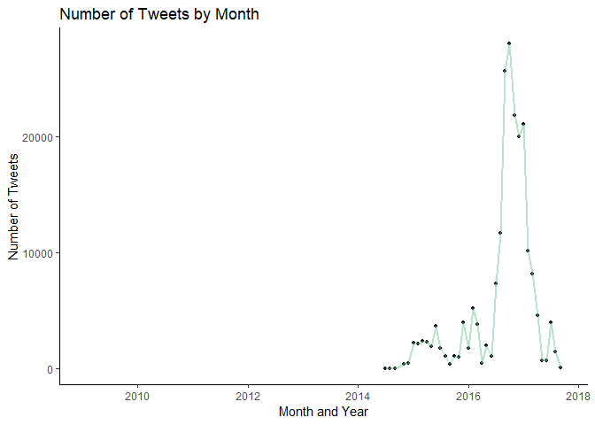

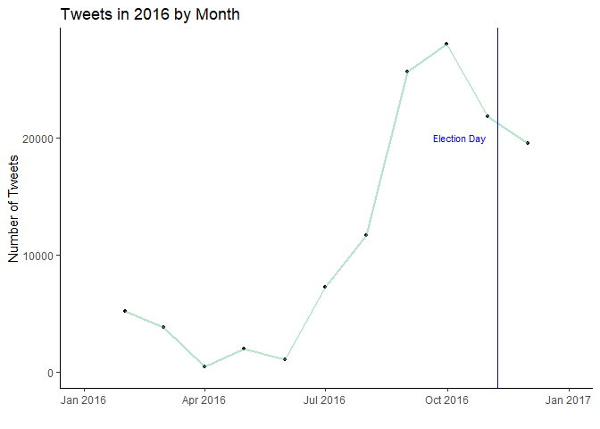

Overlaying of other significant events during the 2016 election and the number of tweets sent by trolls. While this analysis will focus specifically on election day, additional analysis should be able to reflect the messaging related major news stories or events which (presumably) triggered the spike in activity.

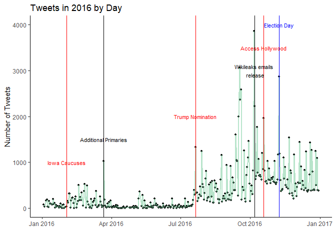

To identify users from retweeted text, a short function parses mentioned users into an edgelist of the sending and receiving user. This list is compared to the dataset of known trolls to differentiate troll and non-troll users. Degree centrality, Betweeness, and Eigen centrality metrics are then calculated from the resulting edgelist. (Closeness centrality was omitted given the highly disconnected nature of the resulting network).

## Network Graph

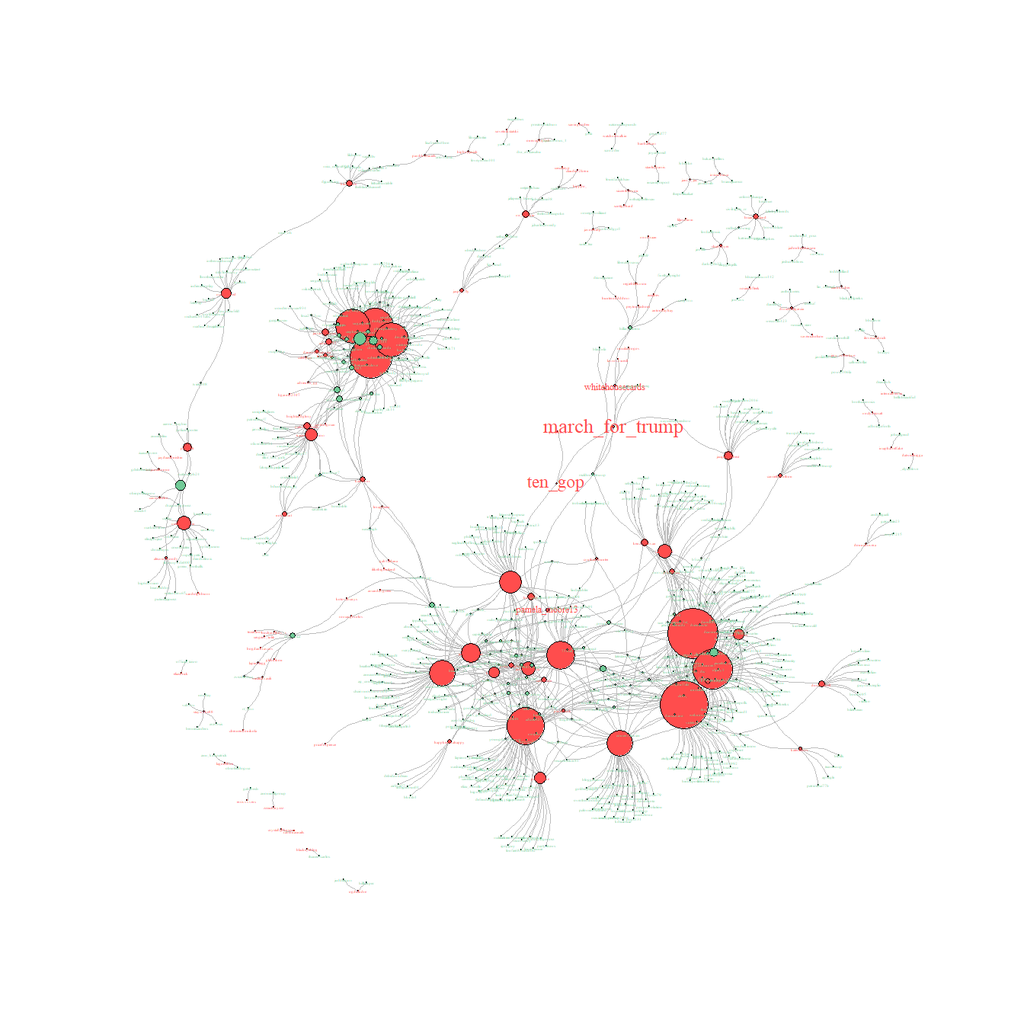

## Text Analysis

Text analysis was performed using a small function to preprocess tweet text including: stemming, stop words removed, puncuation removed, conversion to lower case, numbers removed, white space removed. Additional words removed include “rt”,“amp”,“http”.

Natural language processing using Latent Dirichlet allocation, using k=2 for simplicity, the top 10 terms for each topic are plotted.

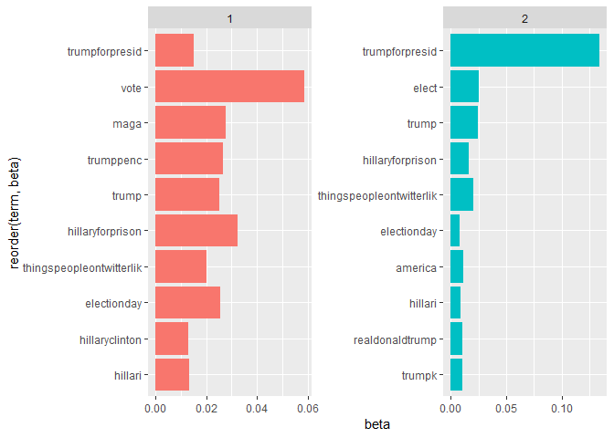

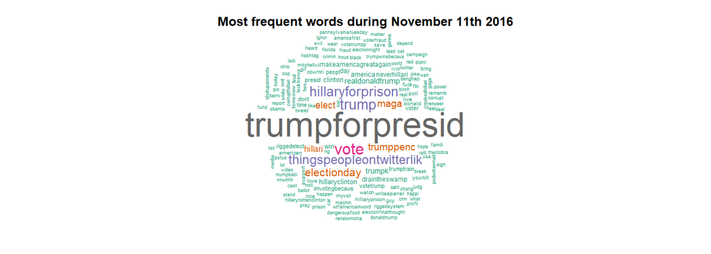

## Community Detection

Using cluster edge betweenness, high betweeness edges are removed sequentially untill the best partitioning of the network is achived. Each community had average betweeness centrality calculated to find the “community of information brokers” in the network. In this example, troll community 9 had the highest average betweeness centrality (2).

```
##    membership       bet
## 9           9 2.0000000
## 11         11 0.2352941
## 1           1 0.0000000
## 2           2 0.0000000
## 3           3 0.0000000
```

Plot of the high betweenness community compared to the wider network graph, community 9 with highest average betweeness is show in red. Other detected communities containing more than 4 trolls shown in shades of green.

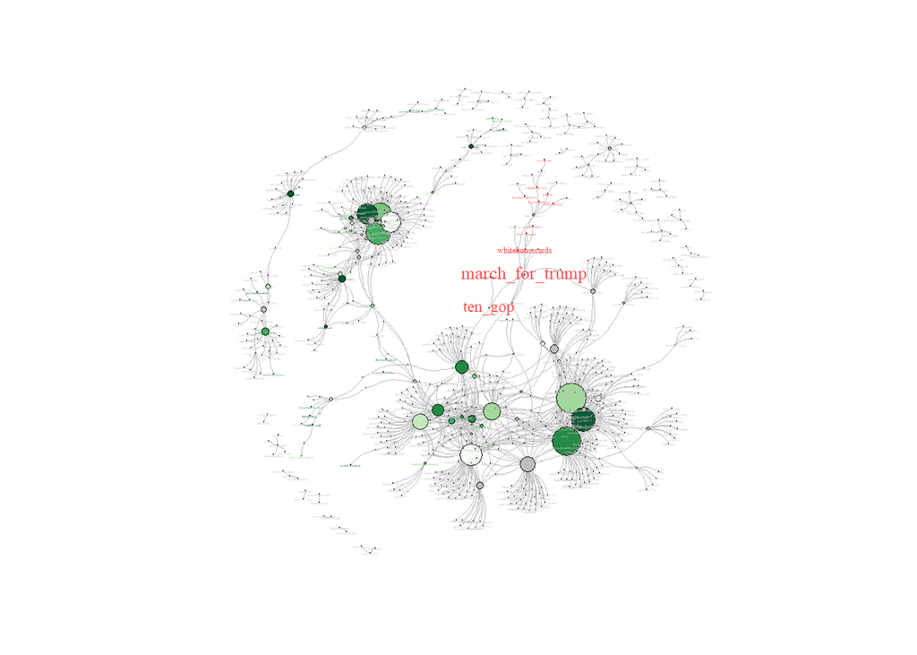

## LDA Tuning

This community was then subset and their tweets were preprocessed as outlined above. On larger data sets LDA tuning has significant performance impacts. On this smaller subset of community 9, LDA tuning was performed to find an optimal K values (between K=2 and k=15) for further topic analysis. The minimize function suggests a k=2, with the maximize function showing k=5. We’ll setting on a K=3 for the remaining analysis.

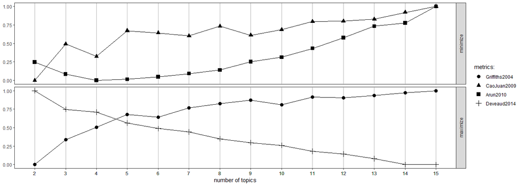

Information brokers community topic plot

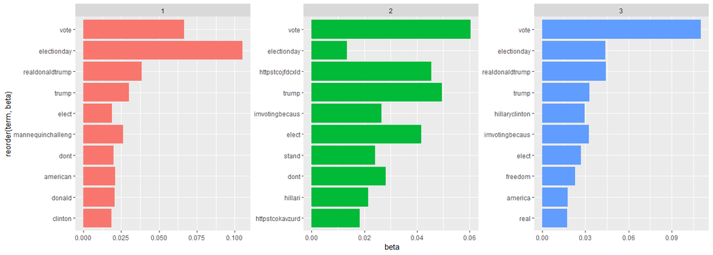